# Mini Project 3 - Forecast

Aaron

July 20, 2016

Using [this URL](https://www.otexts.org/fpp/7) AND the `AirPassengers` data.

```r
library(ggplot2)
library(ggfortify)
library(dplyr)
library(gridExtra)
library(forecast)
```

### Synopsis

The purpose of this analysis is to perform exponential smoothing on the AirPassengers dataset, ultilizing the `holt` function of R. Also this analysis aims to touch on the explanation of exponential smoothing and the Holt-Winters techinique.

### Methods

Load the data set we need for this analysis: `AirPaseengers`.

```r
data("AirPassengers")
```

**Exponential Smoothing**

Forecasts produced using exponential smoothing methods are weighted averages of past observations, with the weights decaying exponentially as the observations get older. In other words, the more recent the observation the higher the associated weight.

**Holt-Winters**

Holt and Winters extended Holt’s method to capture seasonality. The Holt-Winters seasonal method comprises the forecast equation and three smoothing equations: level, trend and seasonal.

We should prefer Holt-Winters over Exponential Smoothing when there is a strong seasonal component in the data.

This analysis is going to forecast **5** period out, from `1961-01` to `1961-05`.

### Analysis

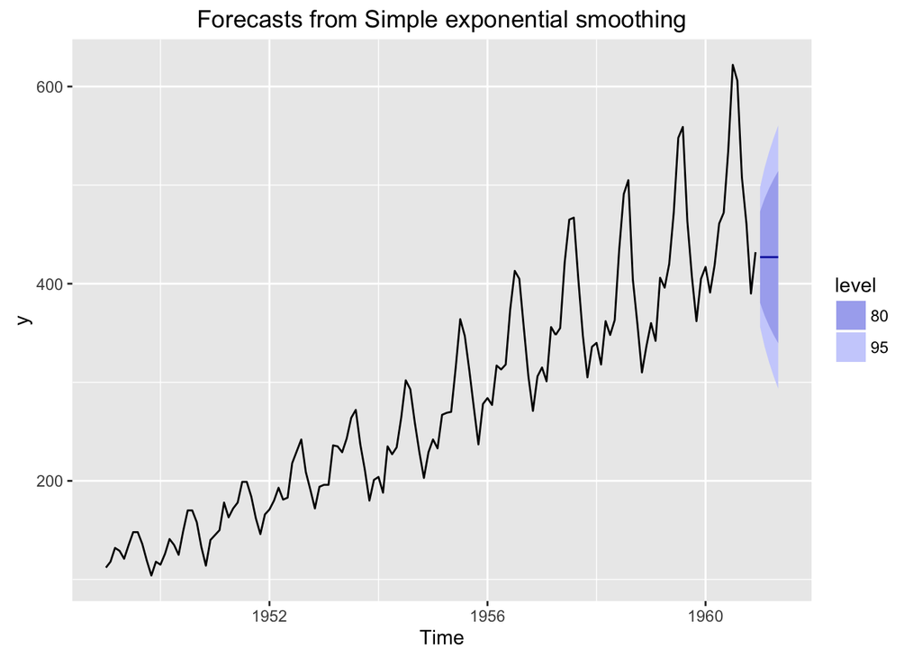

```r
AirPassengers %>%
    ses(alpha = 0.8, beta = 0.2, initial = "simple", exponential=TRUE, h=5) %>%
    autoplot()
```

Zoom in on the prediction area.

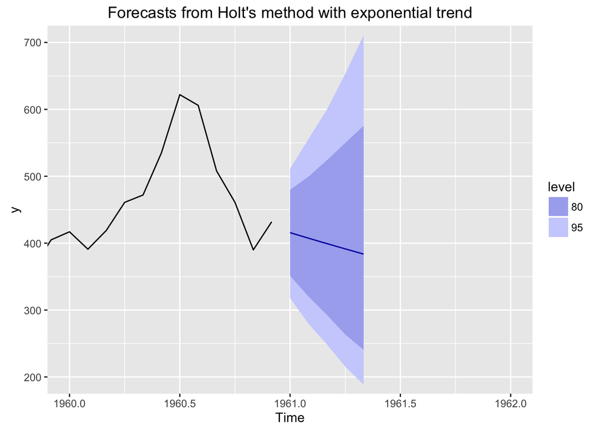

```r
AirPassengers %>%
    holt(alpha = 0.8, beta = 0.2, initial = "simple", exponential=TRUE, h=5) %>%
    autoplot() +
    coord_cartesian(xlim = c(1960,1962),ylim= c(200,700)) ## zoom in on prediction
```